# piaaza_discussion

Rui

10/24/2016

First, read users.json and class_content.json into data frames. Then, create an empty data frame discussion_data, to store the new data subset from class_contentJson.

```r
library(dplyr)
library(jsonlite)
```

```r
library(lubridate)
library(ggplot2)
usersJson <- fromJSON("users.json")
class_contentJson<-fromJSON("class_content.json")
discussion_data<-data.frame(post_id=character(0), author=character(0), type=character(0), when=character(0),subject=character(0), content=character(0), stringsAsFactors=FALSE)
```

Using for loops to extract post information form class_contentJson: post_id: class_contentJson author: either history$uid, or children$uid, or children$children$uid type: either type, or children$type, or children$children$type when: updated, or children$updated, or children$children$updated subject: history$subject content: history$content, or children$subject, or children$children$subject.

```r
for(i in 1:nrow(class_contentJson)){
  post_record<-class_contentJson[i,]
  post_log<-post_record$change_log
  post_replies<-post_record$children
  post_id<-post_log[[1]][[1]][[1]]

  for(l in 1:length(post_record$history[[1]][[1]])){
  author<-ifelse(is.null(post_record$history[[1]][[1]][[l]]),NA,post_record$history[[1]][[1]][[l]])
  subject<-ifelse(is.null(post_record$history[[1]][[4]][[l]]),NA,post_record$history[[1]][[4]][[l]])
  content<-ifelse(is.null(post_record$history[[1]][[3]][[l]]),NA,post_record$history[[1]][[3]][[l]])
  type<-ifelse(is.null(post_record$type),NA,post_record$type)
  when<-ifelse(is.null(post_log[[1]][[5]][[1]]),NA,post_log[[1]][[5]][[1]])
  ob_list<-as.list(c(post_id,author,type,when,subject,content))
  discussion_data<-rbind(discussion_data,setNames(ob_list,names(discussion_data)))
  discussion_data[,1:6]<-apply(discussion_data[,1:6],2,as.character)
  }
  l<-1

  if(length(post_replies[[1]])!=0){
    for(j in 1:nrow(post_replies[[1]])){
        author<-ifelse(is.null(post_replies[[1]][[8]][[j]]),NA,post_replies[[1]][[8]][[j]])
        post_replies_children<-post_replies[[1]][[2]][[j]]
        content<-ifelse(is.null(post_replies[[1]]$subject[[j]]),NA,post_replies[[1]]$subject[[j]])
        when<-ifelse(is.null(post_replies[[1]]$updated[[j]]),NA,post_replies[[1]]$updated[[j]])
        type<-ifelse(is.null(post_replies[[1]]$type[[j]]),NA,post_replies[[1]]$type[[j]])
        ob_list<-as.list(c(post_id,author,type,when,subject,content))
        discussion_data<-rbind(discussion_data,setNames(ob_list,names(discussion_data)))
        discussion_data[,1:6]<-apply(discussion_data[,1:6],2,as.character)

        if(length(post_replies_children)!=0){
          for (k in 1:nrow(post_replies_children)){
            author<-ifelse(is.null(post_replies_children$uid[[k]]),NA,post_replies_children$uid[[k]])
            content<-ifelse(is.null(post_replies_children$subject[[k]]),NA,post_replies_children$subject[[k]])
            when<-ifelse(is.null(post_replies_children$updated[[k]]),NA,post_replies_children$updated[[k]])
            type<-ifelse(is.null(post_replies_children$type[[k]]),NA,post_replies_children$type[[k]])
            ##discussion_data[nrow(discussion_data)+1]<-c(post_id,author,subject,content,type,when)
            ob_list<-as.list(c(post_id,author,type,when,subject,content))
            ob_list<-lapply(ob_list, function(x) ifelse(x == "NULL", NA, x))
            discussion_data<-rbind(discussion_data,setNames(ob_list,names(discussion_data)))
            discussion_data[,1:6]<-apply(discussion_data[,1:6],2,as.character)

          }
      k<-1
    }

  }
    j<-1
}

}
```

export discussion_data into csv

```r
write.csv(discussion_data, file = "Discussion_Data_Oct23.csv")
```

```r
filtered_discussion<-filter(discussion_data, author!="gd6v7134AUa"&author!="hyux2na6B7u"&author!="i4j6wwloouw6vr"&author!="iddrzsd4r7kfm")
piazza_post<-filter(discussion_data,author=="gd6v7134AUa")
david_post<-filter(discussion_data,author=="hyux2na6B7u")
paste("David has", sep = " ", nrow(david_post), "posts")
```

```
## [1] "David has 854 posts"
```

```r
ta1_post<-filter(discussion_data,author=="i4j6wwloouw6vr")
paste("TA1 has", sep = " ", nrow(ta1_post), "posts")
```

```
## [1] "TA1 has 236 posts"
```

```r
ta2_post<-filter(discussion_data,author=="iddrzsd4r7kfm")
paste("TA2 has", sep = " ", nrow(ta2_post), "posts")
```

```
## [1] "TA2 has 43 posts"
```

It will be interesting to see the distribution of posts by time in general (across all users excluding the instructor and TA):

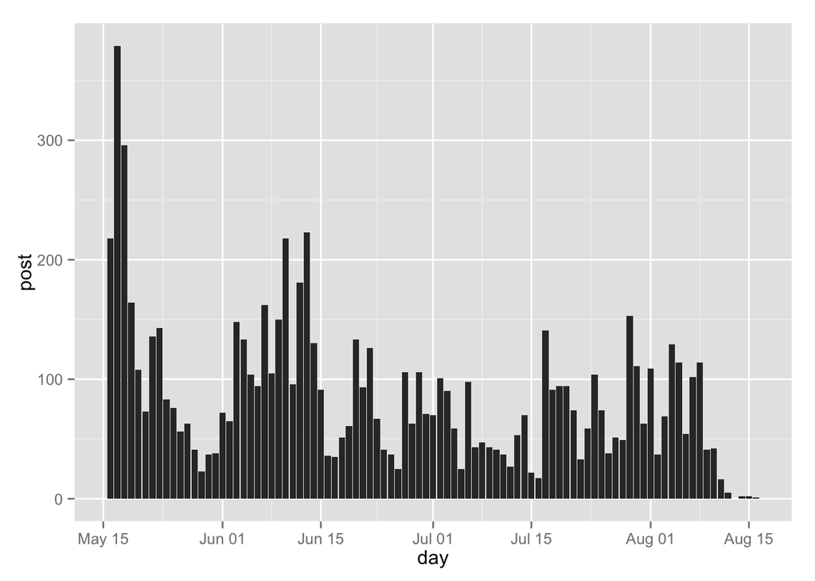

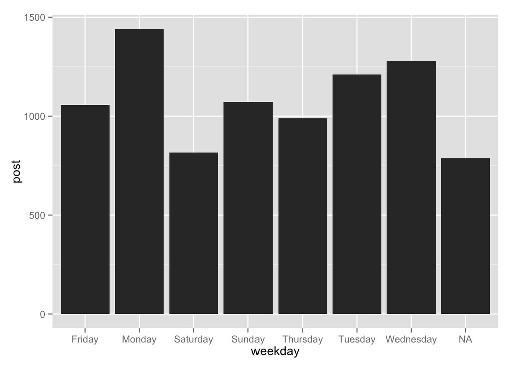